# HW 5: Probability

Due: Friday, Dezember 13 by 11:59 CET

# Fifth Homework: Probability

**Instructions**

# Exercise 1: Another flip-and-draw scenario (14 points)

Consider a flip-and-draw scenario similar to one we discussed in class. First, we flip a coin with a bias of .75 of landing heads. If we observe heads, we draw from urn 1, otherwise from urn 2. The content of the urns is:

- urn 1: 6 white, 3 black, 1 red
- urn 2: 2 white, 5 black, 3 red

## Joint probability table (4 points)

Calculate and write down (maybe using Rmarkdown) the joint probability table for this scenario.

## Marginal probability (2 points)

Calculate the marginal probability of drawing a red ball.

## Conditional probability (4 points)

Calculate the conditional probability of observing a red ball given that the ball we observed was not black. In symbols, calculate: $P(\text{red} \mid \neg \text{black}) = P(\text{red} \mid \{ \text{red}, \text{white} \} )$.

## Bayes rule (4 points)

Using Bayes rule, calculate the probability of a heads outcome given that we observed a draw of a red ball.

# Exercise 2: Bayes rule for medical tests (5 points)

Here is a common mistake in probabilistic reasoning. Jones knows that a medical test has only a 0.5% chance of yielding a false alarm, i.e., diagnose a diseas when in fact there is none. The test indicates that Jones has the diseas. So, Jones thinks that the chance that they are affected is 99.5%. That’s not true. Let’s find out why.

Imagine the following for concreteness. A new blood glucose meter should enable patients to recognize elevated blood glucose. If a certain threshold was exceeded the device gives a warning signal. It is known that 50 of 1000 people have an elevated blood sugar. The device gives a warning signal with 99.5% probability, if the threshold was exceeded. With a probability of 2% the device gives also a warning signal, although the threshold was not exceeded.

Assume a person X to whom an increased blood sugar value has not yet been noticed. How certain can person X be, that he or she has an elevated blood sugar value, if the device gives a warning signal?

# Exercise 3: Bayes’ Rule and Bertrand’s Box Paradox (5 points)

Suppose you are presented with three desks, each with two drawers containing one coin each. There are two kinds of coins: Silver(S) and Gold(G). The desks are such that one has Gold coins in both the drawers **(GG)**, one has silver coins in both **(SS)**, and the third desk has a gold coin in one drawer and a silver coin in the other **(GS)**.

Now, suppose you are free to choose ONE of the three desks at will. After you choose a desk, one of the two drawers is opened at random, and you find a gold coin inside it. *What is the chance that the other drawer also contains a gold coin?*

**Note:** You may be tempted initially to conclude that the said probability of the second drawer also containing a gold coin is 1/2 since the choice is equally likely between the GS desk and the GG desk (SS desk being eliminated now from the scenario). But there is a flaw in this reasoning!

Use Bayes’ rule to find out the answer. The observation here is *‘sighting of a gold coin’* and you are looking for the conditional probability $P(\text{GG} \mid \textit{sight gold})$.

# Exercise 4: Normal distribution from a random walk process (24 points)

Let’s exercise with creating and plotting samples. Let’s assume that there are `n_critters <- 10000` critters. These critters are initially aligned vertically at the same horizontal zero position `critter_positions <- rep(0,n_critters)`. Now each critter will perform `n_steps <- 10000` random steps. Each step moves the critter left or write along the $x$ axis by a random amount between -1 and 1. We can draw such a number using the function `runif(n = XXX, min = -1, max = 1)` which will return a vector of `XXX` samples of numbers between -1 and 1, each sampled uniformly at random.

## Let the critters roam (6 points)

Update the vector `critter_positions` a number of `n_steps` times, by the random procedure described above. The result will be a vector of where each of the critters is located along the $x$ axis after these steps (having wiggled around with great enthusiasm).

## Get summary statistics (2 points)

Calculate the mean and the standard deviation of the critter positions after the wiggling.

## Plot the critter positions (7)

Draw a density plot of two vectors (overlayed, with alpha = 0.5). The first vector is the critter positions you calculated. The second vector is a vector of the same length with samples from a normal distribution, whose mean is the mean of the critter positions, and whose standard deviation is the standard deviation of the critter_positions.

The resulting plot should look (roughly) like this:

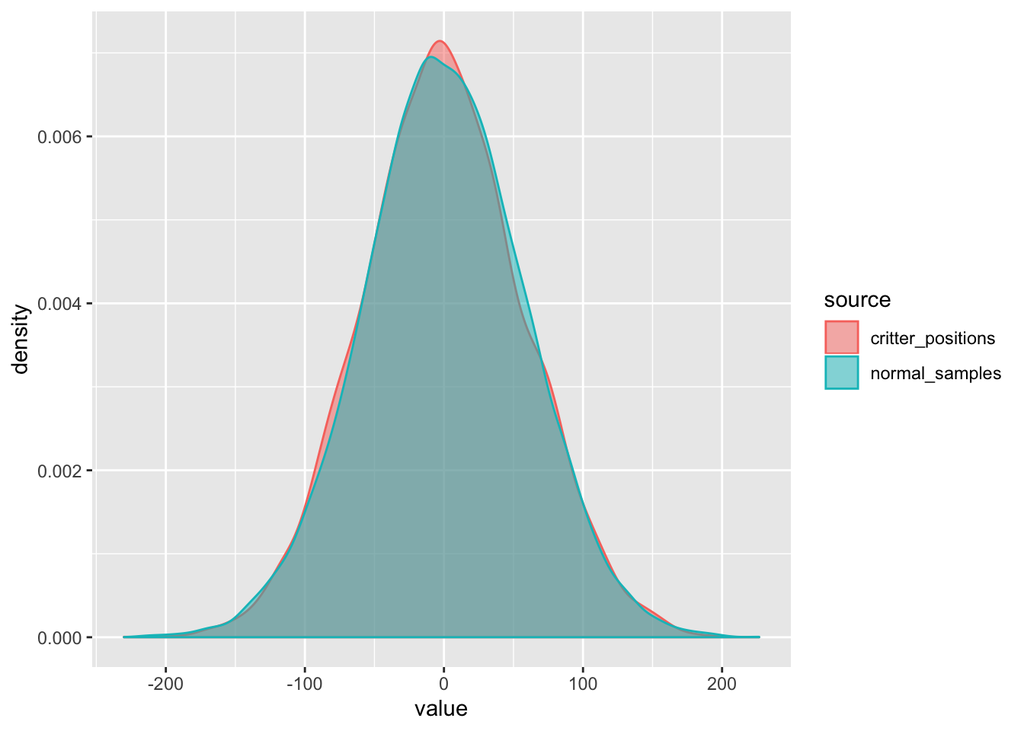

## Repeat for fewer samples (5)

Now do the same thing (initializing, wiggling, and plotting), but for only `n_critters <- 50` critters, while still using the full 10000 samples for the normal distribution. Your result might look like the plot below.

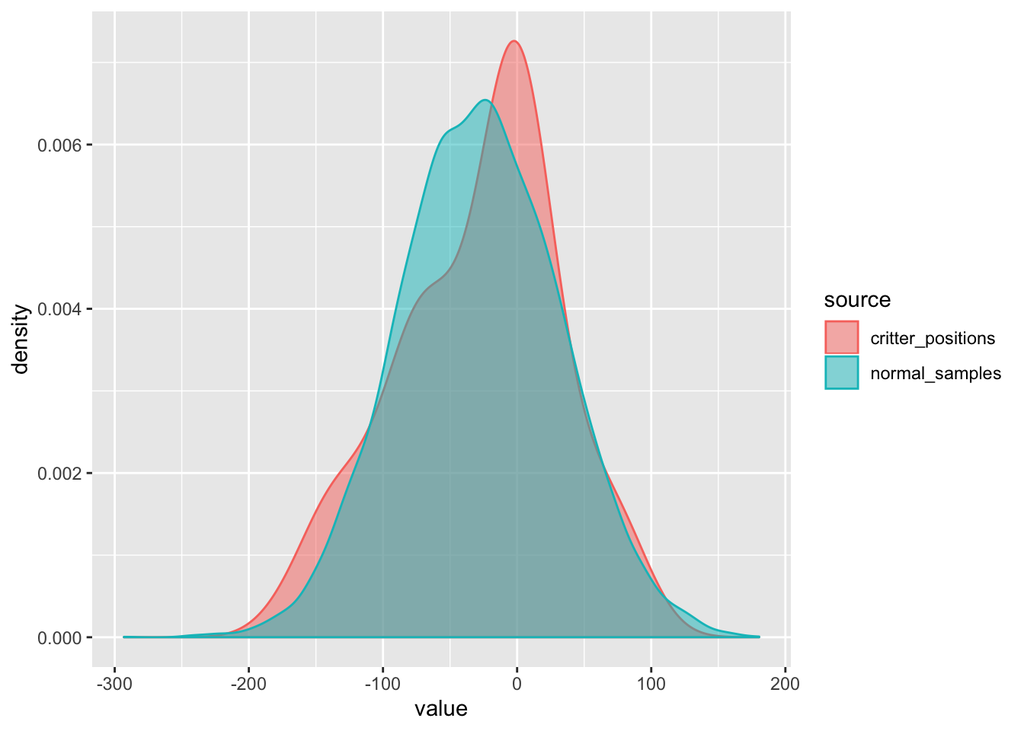

## Interpret the critter walks (4 points)

Name two or three points that are noteworthy about these two simulations with respect to sampling, probability and/or the normal distribution. Be very brief and to-the-point in your answer.

# Reminder

Please submit exercise 1 of the last homework with this homework set as well, even if you have already done so.